# Week 3 DS Recitation

SIBDS 2023@ Columbia

21 June, 2023

## Getting Started

### Tasks:

1. Create a new R project and named it `Week 3 DS Recitation`
2. Put the `week_3_DS_recitation.Rmd` file into the same folder of the R project you just created.
3. Modify the YAML header as follows:

```
---
title: "Week 3 DS Recitation"
date: "21 June, 2023"
author: "SIBDS 2023@ Columbia"
output:
  html_document:
    toc: true
    code_folding: "show"
---
```

Now, knit this `.Rmd` file to make sure it runs as expected.

4. Finally, create a folder within the project folder named `data`. Put the data files we downloaded in Tuesday’s class in to this folder.

## Writing with Data

### Tasks:

1. Write a named code chunk names `sample_df` that creates a dataframe comprised of
   - `random_vec` : A `numeric` variable containing a random sample of size `500` from a normal variable with mean `1` and standard deviation `3`.
   - `logical_vec` : A `logical` vector indicating whether each sampled value is greater than zero, can you do it in the simplest way?
   - `abs_vec`: A `numeric` vector containing the absolute value (using `abs()`) of each element.

```r
# Your answer starts here:
df1 <- tibble(
random_vec = rnorm(500, mean = 1, sd = 3),
logical_vec = random_vec > 0,
abs_vec = abs(random_vec)
)
```

2. Produce a histogram of the absolute value variable just created.

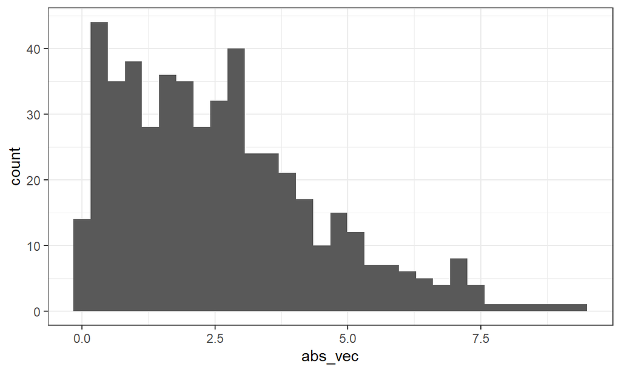

```r
# Your answer starts here:
ggplot(aes(x = abs_vec), data = df1) + geom_histogram()
```

```r
#df1 %>% ggplot(aes(x = abs_vec)) + geom_histogram()
```

4. Fill in the blank using the in-line code giving the mean, median, and standard deviation of `random_vec` (*Hint*: you may need to use the `pull()` function and in `tidyverse`), round them to two decimal places.
   - Mean: 1.07
   - Median: 1.29
   - SD: 3.03

## Data Import

### Tasks:

1. Load the `FAS_pups.csv` dataset. Use both absolute and relative paths.

```r
# Your answer starts here:
working_dir = getwd()
data_dir = paste0(working_dir,"/data/FAS_pups.csv")
# absolute path
pups = read_csv(data_dir)
pups = janitor::clean_names(pups)
# relative path
pups = read_csv("./data/FAS_pups.csv")
pups = janitor::clean_names(pups)

# Take a quick look of your dataset
#summary(pups)

#gtsummary::tbl_summary(pups)

#summarytools::dfSummary(pups)
```

2. Import the `FAS_pups.csv` again with column specifications by setting the `col_type` arguments. What happens if your specifications for column parsing aren’t reasonable (e.g. character instead of double, or vice versa)?

```r
# Let's see what happens together:
```

[output not shown]

## Data Manipulation

### Tasks:

```r
# Your answer starts here:
# filter a
filter(pups, sex == 1)
```

```
## # A tibble: 155 × 6
##    litter_number   sex pd_ears pd_eyes pd_pivot pd_walk
##    <chr>         <dbl>   <dbl>   <dbl>    <dbl>   <dbl>
##  1 #85               1       4      13        7      11
##  2 #85               1       4      13        7      12
##  3 #1/2/95/2         1       5      13        7       9
##  4 #1/2/95/2         1       5      13        8      10
##  5 #5/5/3/83/3-3     1       5      13        8      10
##  6 #5/5/3/83/3-3     1       5      14        6       9
##  7 #5/4/2/95/2       1      NA      14        5       9
##  8 #4/2/95/3-3       1       4      13        6       8
##  9 #4/2/95/3-3       1       4      13        7       9
## 10 #2/2/95/3-2       1       4      NA        8      10
## # ℹ 145 more rows
```

```r
pups %>% filter(., sex == 1)
```

```
## # A tibble: 155 × 6
##    litter_number   sex pd_ears pd_eyes pd_pivot pd_walk
##    <chr>         <dbl>   <dbl>   <dbl>    <dbl>   <dbl>
##  1 #85               1       4      13        7      11
##  2 #85               1       4      13        7      12
##  3 #1/2/95/2         1       5      13        7       9
##  4 #1/2/95/2         1       5      13        8      10
##  5 #5/5/3/83/3-3     1       5      13        8      10
##  6 #5/5/3/83/3-3     1       5      14        6       9
##  7 #5/4/2/95/2       1      NA      14        5       9
##  8 #4/2/95/3-3       1       4      13        6       8
##  9 #4/2/95/3-3       1       4      13        7       9
## 10 #2/2/95/3-2       1       4      NA        8      10
## # ℹ 145 more rows
```

```r
pups %>% filter(sex == 1)
```

```
## # A tibble: 155 × 6
##    litter_number   sex pd_ears pd_eyes pd_pivot pd_walk
##    <chr>         <dbl>   <dbl>   <dbl>    <dbl>   <dbl>
##  1 #85               1       4      13        7      11
##  2 #85               1       4      13        7      12
##  3 #1/2/95/2         1       5      13        7       9
##  4 #1/2/95/2         1       5      13        8      10
##  5 #5/5/3/83/3-3     1       5      13        8      10
##  6 #5/5/3/83/3-3     1       5      14        6       9
##  7 #5/4/2/95/2       1      NA      14        5       9
##  8 #4/2/95/3-3       1       4      13        6       8
##  9 #4/2/95/3-3       1       4      13        7       9
## 10 #2/2/95/3-2       1       4      NA        8      10
## # ℹ 145 more rows
```

```r
# filter b
b_1 = pups %>% filter(pd_walk < 11, sex == 1) #1
b_2 = pups %>% filter(pd_walk < 11 & sex == 1) #2

# c
pups$pd_pivot_7 = pups$pd_pivot - 7
pups["pd_pivot_7_2"] = pups["pd_pivot"] - 7
#pups[,9] = pups[,5] - 7 Better not

# d
```

```r
# Your answer starts here:
pups_piped =
  read_csv("./data/FAS_pups.csv") %>%
  janitor::clean_names() %>%
  filter(sex == 1) %>%
  select(-pd_ears) %>%
  mutate(pd_pivot_indicator = pd_pivot > 7)
```